# 2025년 06월 04일 수요일 (28일차)

# 📜 목차

- **선형 자료구조**
  - [**queue**]
    - Linear Queue (선형 큐)
    - Circular Queue (원영 큐 or 환영큐)
    - Queue class
  - [**Doubly Linked List**] 파이썬으로 `다중 연결 리스트` 구현하기
- **알고리즘**
  - 재귀호출
    - 피보나치 수열
  - 정렬
    - Selection Sort

# 🟩 자료구조(Data Structure) 2

# 🟩 [**Queue**] 파이썬으로 `큐` 구현하기

- 비유: 줄 서기
  - 편의점 계산대 줄을 생각해 보세요: 먼저 온 사람이 먼저 계산하고 나감 / 나중에 온 사람은 그 뒤에 줄 서서 기다림
- 특징
  - 선입선출 (FIFO: First In, First Out)
  - 먼저 들어온게 먼저 나가는 일부 메모리 공간을 잘라서 우리가 키보드를 누르면 그 값이 버퍼라는 공강에 먼저 들어갔다가 엔터키 누르면 그때 메모리로 들어간다.
  - 데이터를 모아두었다가 한번에 처리하는 방식
- 종류
  - 선형 큐 (Linear Queue)
  - 원형 큐 (Circular Queue) or 환형 큐
  - 덱 (Deque) or 양방향 큐
  - 우선순위 큐 (Priority Queue)
- 명령어 형태
  - put - 큐에 데이터 넣는 연산
  - get - 큐에서 데이터 가져오기 연산
  - is_full - 큐가 차면 True 아니면 False
  - is_empty - 큐가 비었는지 True 아니면 False
  - peek - 큐의 맨처음값 하나 확인하는 용도

#### 큐 이해 사진

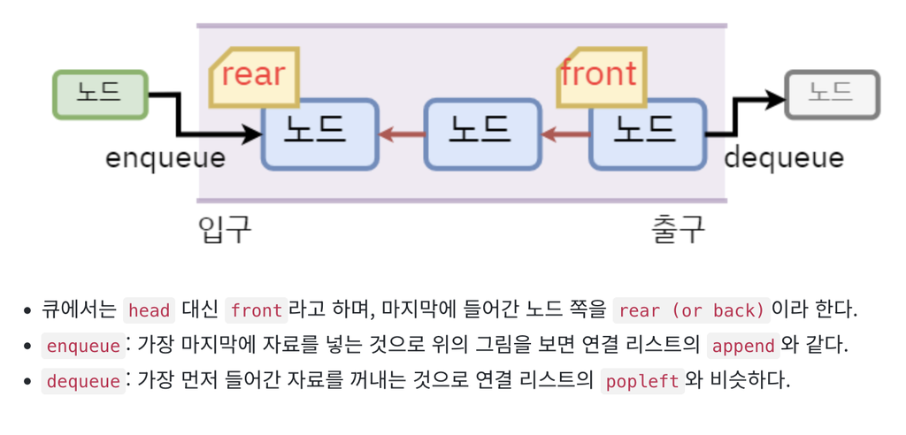

사진 출처 : https://wikidocs.net/192523

### 🟡 Linear Queue (선형 큐)

| 용어 | 설명 |
| --- | --- |
| 큐 (Queue) | 선입선출(FIFO) 방식의 선형 자료구조 |
| Enqueue | 데이터를 큐에 추가하는 연산 (뒤에 넣음) |
| Dequeue | 데이터를 큐에서 제거하는 연산 (앞에서 뺌) |
| Front | 큐의 가장 앞에 있는 데이터 (곧 나갈 데이터) |
| Rear | 큐의 가장 뒤에 있는 데이터 (최근 들어온 데이터) |

```
`큐의 흐름 (선입선출)`

   [Front]                  [Rear]
      ↓                       ↓
   ┌───────┬───────┬───────┬───────┐
   │   1   │   2   │   3   │   4   │
   └───────┴───────┴───────┴───────┘
     ↑ (dequeue)         ↑ (enqueue)
```

- 개념
  - Front = 어디에서 꺼낼 것인지
  - Rear = 어디에 저장할 것인지

### 🟡 Circular Queue (원영 큐 or 환영큐)

#### ⚫️ 왜 `선형큐 or 환영큐`를 사용하는가?

**선형 큐(Linear Queue)**는 데이터를 enqueue → dequeue 하다 보면 앞에 공간이 생겨도 다시 사용하지 못하는 문제가 생깁니다! 그래서 바로 원형큐를 공부하는 것이다!

```
배열 크기: 5

초기 상태: [ _, _, _, _, _ ]
enqueue 3개: [ 1, 2, 3, _, _ ]
dequeue 2개: [ _, _, 3, _, _ ] ← 앞 공간이 비었지만 못 씀
enqueue 2개: [ _, _, 3, 4, 5 ]
더 이상 enqueue 불가!
```

원형 큐는 배열의 처음과 끝이 연결되어 있다고 간주하여, 배열의 끝에 도달해도 앞부분에 빈 공간이 있다면 그곳에 데이터를 저장할 수 있게 합니다. 마치 원형 트랙과 같습니다.

#### 원형큐 참고 사진

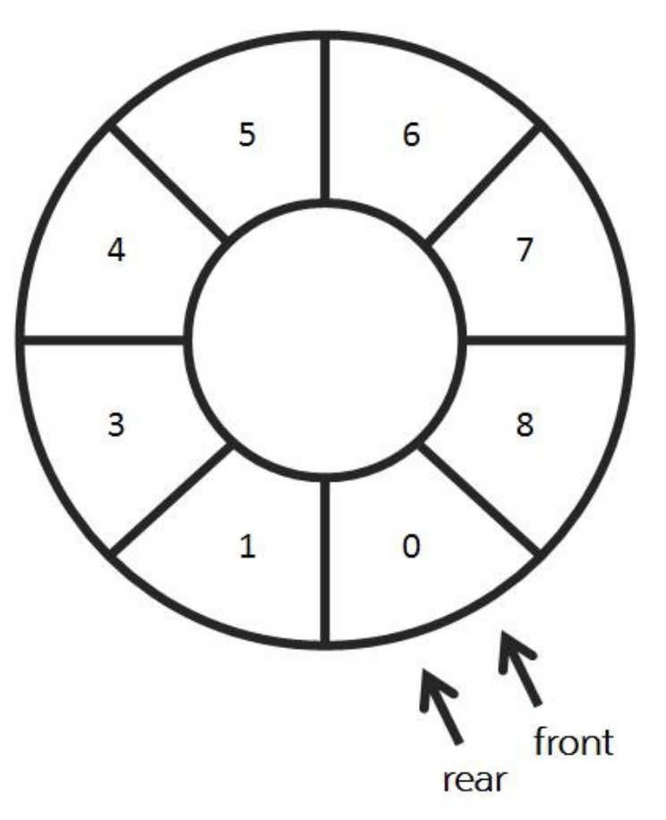

사진 출처 : https://mengu.tistory.com/110

### 🟡 Circular Queue class로 만들기

```python
class MyQueue:
    def __init__(self, size=10):
        # MyQueue 클래스의 생성자입니다. 큐의 최대 크기(용량)를 설정합니다.
        if size < 10: # 큐의 최소 크기를 10으로 강제합니다.
            size = 10
        self.size = size # 큐의 최대 크기를 저장하는 인스턴스 변수입니다.

        # self.queue는 큐의 실제 데이터 요소들이 저장될 공간입니다.
        # self.size만큼의 길이를 가진 리스트를 생성하며, 모든 요소를 None으로 초기화합니다.
        # 이는 MyQueue가 미리 정해진 고정된 크기(self.size)를 가진 배열(파이썬 리스트)로 구현되었음을 의미합니다.
        self.queue = [None] * self.size   # 해당 size 길이를 가진 배열인데 모든 초기값은 None이다.

        # self.front와 self.rear는 큐의 실제 데이터가 저장된 self.queue 리스트의 **인덱스를 가리키는 숫자(정수)**입니다.
        # 두 인덱스는 0으로 초기화됩니다.
        # 이 구현에서 self.front와 self.rear는 **절대로 음수가 될 일이 없으며**, 항상 0 이상의 정수 값을 유지합니다 [대화 내용].
        self.front = 0      # 큐에서 가장 먼저 나올(dequeue될) **데이터의 바로 앞 위치**를 가리키는 인덱스입니다.
                            # 즉, `get()` 연산을 할 때 `front`를 먼저 한 칸 이동시키고 그 위치의 데이터를 가져옵니다.
        self.rear = 0       # 큐에 가장 마지막으로 들어간(enqueue될) **데이터의 위치**를 가리키는 인덱스입니다.
                            # `put()` 연산을 할 때 `rear`를 먼저 한 칸 이동시키고 그 위치에 데이터를 저장합니다.
        # 초기 상태에서는 `self.front`와 `self.rear`가 같은 위치(0)를 가리키므로, 큐가 비어있음을 나타냅니다.

        self.data_count = 0   # 지금 데이터가 몇개 있는지에 대해서 계산하기 위해서 만들었습니다. (사실 필요없음)
                                # 그냥 put에 +1 / get에 -1 해주면 끝이라서 아주 간편합니다.

    def is_empty(self):
        # 큐가 비어있는지 확인하는 메서드입니다.
        # `self.rear`와 `self.front`가 같은 위치(같은 인덱스 값)를 가리키고 있다면 큐는 완전히 비어있는 상태입니다.
        if self.rear == self.front:
            return True
        return False

    def is_full(self):
        # 큐가 가득 찼는지 확인하는 메서드입니다.
        # 이것이 **원형 큐의 핵심적인 가득 참 조건**입니다.
        # `(self.rear + 1) % self.size`는 `rear`를 한 칸 이동시켰을 때의 다음 인덱스입니다.
        # 이 인덱스가 `self.front`와 같아진다면 큐는 가득 찬 것으로 판단합니다.
        # 이 구현 방식은 큐가 비어있는 상태(`front == rear`)와 가득 찬 상태를 구분하기 위해 **의도적으로 하나의 공간을 항상 비워둡니다**.
        # 따라서 `self.size`가 10으로 초기화된 경우, 실제로는 `self.size - 1`개, 즉 9개의 데이터만 저장할 수 있습니다.
        if (self.rear + 1) % self.size == self.front:
            return True
        return False

    def put(self, data):
        # 큐에 데이터를 삽입하는 메서드입니다 (Enqueue).
        """
        `rear` 포인터를 하나 증가시킨 다음, `% self.size` 연산으로 나머지를 구하고,
        그 위치에 데이터를 넣습니다.
        """
        if self.is_full(): # 데이터를 삽입하기 전에 큐가 가득 찼는지 먼저 확인합니다.
            print("queue is full") # 가득 찼다면 "queue is full" 메시지를 출력하고.
            return # 데이터 삽입을 중단합니다.

        self.data_count += 1

        # `rear` 포인터를 다음 위치로 **원형으로** 이동시킵니다.
        # 🔥 모듈러 연산(`% self.size`)이 핵심입니다. / 큐는 끝까지 가면 다시 처음으로 돌아와야 하기 때문에, self.rear += 1 하지 않고, %self.size (모듈로 연산)를 붙음.
        # 이 연산을 통해 `rear`의 인덱스가 `self.queue` 리스트의 크기(`self.size`)를 벗어나지 않고, 배열의 끝에 도달하면 다시 0으로 돌아와 배열의 처음으로 순환하게 만듭니다.
        self.rear = (self.rear + 1) % self.size  # 🔥🔥 ‼️ [정수기준 나눗셈] 결과적으로 처음부터 index[1]부터 채워 나간다.
        self.queue[self.rear] = data # 새롭게 계산되어 이동된 `self.rear` 위치에 전달받은 `data`를 저장합니다.

        # ‼️ 알아야할 어이가 없는 내용
        # 실질적으로 index 1 부터 채우게 되면
        #     [None, 'A', B, C, D, E, F, G, H, I]
        #       ↑                              ↑
        #     front                           rear (index[9] 상태)
        # 이렇게 되면... 실제로는 10개의 데이터를 다 채우지 못하는거네? = 맞다
        # 이유는 큐 상태를 표현할 때 front와 rear가 같은 위치에 있게 될 경우, 큐가 비었는데, 가득 찼는지를 구분하지 못하게 되기 때문이다.
        # front와 rear가 같은 위치에 오지 못하게 하기 위해서 이렇게 하는 것이라고 합니다.

    def get(self):
        # 큐에서 데이터를 추출하는 메서드입니다 (Dequeue).
        """
        `front` 포인터를 증가시키고, 그 위치의 값을 반환해야 합니다.
        """
        if self.is_empty(): # 큐가 비어있는지 먼저 확인합니다.
            print("queue is empty") # 비어있다면 "queue is empty" 메시지를 출력하고.
            return # 데이터 추출을 중단합니다.

        self.data_count -= 1

        # `front` 포인터를 다음 위치로 **원형으로** 이동시킵니다. (처음에는 당연히 index 1로 이동을 먼저 하겠지)
            # 이동한 이 위치가 처음에 큐의 맨 앞(가장 먼저 들어온) 데이터가 있는 위치가 됩니다.
        self.front = (self.front + 1) % self.size  # ‼️ [정수기준 나눗셈]
        data = self.queue[self.front] # 이동된 `self.front` 위치의 데이터를 가져옵니다.
        self.queue[self.front] = None     # (주석 처리되어 있지만) 추출된 자리를 `None`으로 비워주는 것은 메모리 정리를 위해 좋은 습관입니다.
        return data # 추출한 데이터를 반환합니다.

    def peek(self):
        # 큐의 맨 앞 데이터를 확인하는 메서드입니다. 데이터는 큐에서 **제거되지 않습니다**.
        """
        `front`를 증가시켜서 그 위치 값을 반환해야 합니다.
        하지만 `front` 포인터 자체는 변경하면 안 됩니다.
        """
        if self.is_empty(): # 큐가 비어있는지 먼저 확인합니다.
            print("queue is empty")
            return None

        # 실제 `front` 포인터는 변경하지 않고, 다음에 나올 요소의 위치를 임시로 계산합니다.
        temp = (self.front + 1) % self.size
        return self.queue[temp] # 계산된 임시 위치(`temp`)의 데이터를 반환합니다.

    def print_queue(self):
        # 큐의 내부 리스트(`self.queue`)의 현재 상태를 출력합니다.
        print(self.queue)

    def print_front(self):
        # `front` 포인터의 현재 인덱스 값을 출력합니다.
        print(self.front)

    def print_rear(self):
        # `rear` 포인터의 현재 인덱스 값을 출력합니다.
        print(self.rear)

    def print_size(self):
        # 큐의 최대 크기(`self.size`)를 출력합니다.
        print(self.size)

if __name__ == '__main__':
    # MyQueue 클래스의 사용 예시 코드입니다.
    q = MyQueue() # `size` 기본값인 10으로 MyQueue 인스턴스를 생성합니다.
                    # 이 큐는 `size - 1`개, 즉 9개까지의 데이터를 저장할 수 있습니다.

    # ---------------------------------------------------------------------------------
    # ----------- `put()` 메서드 호출 예시 -----------
    q.put("A") # `rear`가 1로 이동하고 `queue`에 "A" 저장.
    q.put("B") # `rear`가 2로 이동하고 `queue`에 "B" 저장.
    q.put("C") # `rear`가 3로 이동하고 `queue`에 "C" 저장.
    q.put("D") # `rear`가 4로 이동하고 `queue`에 "D" 저장.
    q.put("E") # `rear`가 5로 이동하고 `queue`에 "E" 저장.
    q.put("F") # `rear`가 6로 이동하고 `queue`에 "F" 저장.
    q.put("G") # `rear`가 7로 이동하고 `queue`에 "G" 저장.
    q.put("H") # `rear`가 8로 이동하고 `queue`에 "H" 저장.
    q.put("I") # `rear`가 9로 이동하고 `queue`에 "I" 저장.
                # 이 시점에서 `front = 0`, `rear = 9`이며, 9개의 데이터가 모두 저장된 상태입니다.

    q.put("J")  # **여기서 큐가 가득 찼다고 판단하여 "J"는 삽입되지 않습니다.**.
                # `is_full()` 메서드 검사: `(self.rear + 1) % self.size == self.front`
                #                           `(9 + 1) % 10 == 0`
                #                           `10 % 10 == 0`
                #                           `0 == 0` -> 조건이 True가 됩니다! 큐가 꽉 찼다고 판단.
                # 따라서 "queue is full" 메시지가 출력되고 `return`되어 "J"는 큐에 들어가지 못합니다.

    print(q.queue) # 현재 큐의 리스트 상태를 출력합니다.
                    # 예시: `[None, 'A', 'B', 'C', 'D', 'E', 'F', 'G', 'H', 'I']` (9개의 데이터와 1개의 None 슬롯)

    # ---------------------------------------------------------------------------------
    # ----------- `get()` 메서드 호출 예시 -----------
    q.print_front()
    print(q.get()) # "A"를 추출하고 `front`가 1로 이동합니다.
    q.print_front()
    print(q.get()) # "B"를 추출하고 `front`가 2로 이동합니다.
    q.print_front()
    print(q.get())
    print(q.get())
    print(q.get())

    q.print_queue() # 현재 규의 리스트 상태 출력


    # ---------------------------------------------------------------------------------
    # ----------- `print_front()`, `print_rear()`, `print_size()` 메서드 호출 예시 -----------
    print('----------------------------------------')
    q.print_front()
    q.print_rear()
    q.print_size()
```

```
queue is full
[None, 'A', 'B', 'C', 'D', 'E', 'F', 'G', 'H', 'I']
0
A
1
B
2
C
D
E
[None, None, None, None, None, None, 'F', 'G', 'H', 'I']
----------------------------------------
5
9
10
```

### 🟡 은행 번호표 뽑기 예제

은행에 가면 순번뽑기  
1.은행원 - 작업완료 -> 몇번 손님 나오세요  
2.고객 - 번호뽑기 -> 대기인원

```python
class BackNumber:
  def __init__(self):
    self.number = 0  # 번호가 0 부터 ~~~
    self.cnt = 0
    self.queue = MyQueue(500) # 큐의 크기를 500

  def menu_customer(self):
    self.number += 1
    self.cnt += 1
    self.queue.put(self.number)
    print(f"대기인원 {self.cnt}" )
    print(f"고객님의 번호는 {self.number} 입니다.")

  def menu_banker(self):
    # 큐에서 번호를 하나를 꺼낸다.
    if self.queue.is_empty():
      return
    number = self.queue.get()
    print(f"{number}번 고객님 창구 앞으로 와주세요!")
    self.cnt -= 1
    print(f"대기인원 {self.cnt}")

  def main(self):
    while True:
      sel = input("1.고객 | 2.은행원 | 3.종료")
      if sel == "1":
        self.menu_customer()
      elif sel == "2":
        self.menu_banker()
      elif sel == "3":
        return
      else: print("잘 못 입력하셨습니다.")


if __name__ == '__main__':
  b = BackNumber()
  b.main()
```

```
대기인원 1
고객님의 번호는 1 입니다.
대기인원 2
고객님의 번호는 2 입니다.
1번 고객님 창구 앞으로 와주세요!
대기인원 1
대기인원 2
고객님의 번호는 3 입니다.
대기인원 3
고객님의 번호는 4 입니다.
2번 고객님 창구 앞으로 와주세요!
대기인원 2
3번 고객님 창구 앞으로 와주세요!
대기인원 1
4번 고객님 창구 앞으로 와주세요!
대기인원 0
대기인원 1
고객님의 번호는 5 입니다.
```

# 🟩 [**Doubly Linked List**] 파이썬으로 `다중 연결 리스트` 구현하기

```python
class Node:
  def __init__(self, data=None):
    self.prev = None   # 앞을 가르키는 node 주소
    self.data = data
    self.next = None   # 뒤를 가르키는 node 주소

# 더미노드로 생각합니다.
class DoubleLinkedList:
  def __init__(self):
    self.head = Node()  # 리스트 전체의 시작을 가리킨다.
    self.tail = Node()  # 리스트 전체의 끝을 가리킨다.
    self.head.prev = self.head
    self.head.next = self.tail
    self.tail.prev = self.head
    self.tail.next = self.tail
    # initialized 상태 >>>     head <=> tail

  # ------------------------------------------------------------
  #        head                                     tail
  #        node                node                 node
  # [pr | data | ne]  →  [pr | data | ne]  →  [pr | data | ne]
  # ------------------------------------------------------------
  def insert_head(self, data):  # 맨 앞에 넣는 것
    temp = Node(data)
    # 기존에 head에 있던 주소를 가져와야겠지?
    temp.prev = self.head
    temp.next = self.head.next
    # 2. 다음에 head 오른쪽에 있던 노드의 prev 주소도 바꿔줘야겠지?  # 🔥 나중에 순서 문제가 있었음 이거 먼저 해줬어야 합니다.
    self.head.next.prev = temp
    # 1. 이제 head를 정의해줘야겠지? 바뀌었으니깐
    self.head.next = temp


  def insert_tail(self, data):  # 맨 뒤에 넣는 것
    temp = Node(data)
    temp.prev = self.tail.prev
    temp.next = self.tail
    self.tail.prev.next = temp  # 🔥 이거 먼저 해줬어야 합니다.
    self.tail.prev = temp


  def print_prev(self):
    temp = self.tail.prev
    print(f"TAIL < ", end="")
    while temp != self.head:   # 더미노드가 서로를 link하고 있지 않다면.. temp.prev가 head를 가르킬 때까지 동작하겠다!
      print(f"{temp.data}", end=" < ")
      temp = temp.prev   # 계속 이전으로 이동하면서 print 한다.
    print(f"HEAD")

  def print_next(self):
    temp = self.head.next
    print(f"HEAD > ", end="")
    while temp != self.tail:
      print(f"{temp.data}", end=" > ")
      temp = temp.next   # 계속 뒤로 이동하면서 print 한다.
    print(f"TAIL")

  def delete_head(self):
    if self.head.next == self.tail:  # 지금 비었는지 확인하는 것입니다.
      return
    # head.next가 가르키는 것을 한단계 건너뛰어서 linked 해주면 됩니다.
    self.head.next = self.head.next.next
    # 지금 head.next가 원하는대로 바뀐 상태이기 때문에 그대로 prev는 head로 해주면 됩니다.
    self.head.next.prev = self.head

  def delete_tail(self):
    if self.head.next == self.tail:  # 지금 비었는지 확인하는 것입니다.
      return
    # tail.prev가 가르키는 것을 한단계 건너뛰어서 linked 해주면 됩니다.
    self.tail.prev = self.tail.prev.prev
    # 지금 tail.prev가 바뀐 상태이기 때문에 그대로 next는 tail로 해주면 됩니다.
    self.tail.prev.next = self.tail


dlist = DoubleLinkedList()

# -----------------------------
# head 추가해보기
print('------------------ 추가 ------------------')
dlist.insert_head("A")
dlist.insert_head("B")
dlist.insert_head("C")
dlist.insert_head("D")
dlist.insert_head("E")
dlist.insert_head("F")
dlist.insert_head("G")
dlist.insert_head("H")

# 앞에서 부터 print
dlist.print_next()


# -----------------------------
# tail도 추가해보기
dlist.insert_tail("I")

# 뒤에서부터 print
dlist.print_prev()

# 다시 print 해보기
dlist.print_next()


# -----------------------------
# head 삭제해보기
print('\n------------------ 삭제 ------------------')
dlist.delete_head()

# 앞에서 부터 print
dlist.print_next() # H 삭제


# -----------------------------
# tail 삭제해보기
dlist.delete_tail()  # I 삭제
dlist.delete_tail()  # A 삭제

# 앞에서 부터 print
dlist.print_next()
```

```
------------------ 추가 ------------------
HEAD > H > G > F > E > D > C > B > A > TAIL
TAIL < I < A < B < C < D < E < F < G < H < HEAD
HEAD > H > G > F > E > D > C > B > A > I > TAIL

------------------ 삭제 ------------------
HEAD > G > F > E > D > C > B > A > I > TAIL
HEAD > G > F > E > D > C > B > TAIL
```

# 🟩 재귀호출

- 종료가 없으면 종료되지 않는다....
- 서로 계속 호출을 반복하면 스택에 계속 쌓여서 stack over flow 가 발생한다...
- 무한대로 호출하지 않게 만들어주는게 핵심입니다.
- 장점 : 코드를 간결하게, 트리순회 시 재귀호출이 유용, 퀵정렬 알고리즘
- 단점 : 메모리를 많이 사용하고 속도 느림

```python
# 반드시 언제가는 끝내야 해서, 매개변수를 갖고 다니면서 이깝승ㄹ 증가 또는 감소를 시켜서 끝나느 상황을 만들어줘야 한다.
# 1 ~ 10 까지 재귀호출로 출력을 하려고 합니다. (그냥 해보는 것)
# 1, 2, 3, 4, 5, 6, 7, 8, 9, 10

def recursive_call(n):
  # 재귀로 근데 이거 무한하게 돌아버립니다. 그래서 종료 조건이 매우 중요합니다.
  if n > 10 :
    return
  print(n)
  recursive_call(n+1)

recursive_call(0)

# 차라리 for문을 쓰자는 생각을 할 수 있습니다.abs


def recursive_call2(n):
  if n < 0 :
    return
  print(n)
  recursive_call2(n-1)


recursive_call2(10)
```

```
0
1
2
3
4
5
6
7
8
9
10
10
9
8
7
6
5
4
3
2
1
0
```

## 🟢 재귀호출 - 피보나치수열

f(1) = 1  
f(2) = 1  
f(3) = f(1) + f(2)  
f(4) = f(2) + f(3)  
f(5) = f(3) + f(4)  
f(6) = f(4) + f(5)

규칙이 존재함.

f(n) = f(n-2) + f(n-1)

```python
def fibonacci(n):
  if n == 1 or n == 2:
    return 1
  return fibonacci(n-2) + fibonacci(n-1)

print("3번째 요소", fibonacci(3))
print("6번째 요소", fibonacci(6))
```

```
3번째 요소 2
6번째 요소 8
```

```python
# 문제 - 1~n까으의 합계를 구하는 걸 재귀호출로 작성하기
# 내가 직접 풀어보기

def fibonacci2(cnt, n):
  if n < 1 :
    return cnt

  cnt = cnt

  cnt += n
  print(n, cnt)
  fibonacci2(cnt, n-1)


fibonacci2(0, 10)
```

```
10 10
9 19
8 27
7 34
6 40
5 45
4 49
3 52
2 54
1 55
```

```python
# 문제 - 1~n까으의 합계를 구하는 걸 재귀호출로 작성하기
# 같이 풀어보기

# f(n) = n + f(n-1)  # 🔥 이런 규칙을 찾아내는 것이 정말 중요합니다.
# f(1) = 1
# f(2) = f(1) + 2
# f(3) = f(2) + 3

def fibonacci3(n):   # 🔥 막상 쓰고나니 어떻게 동작하는 것인지 이해가 힙듭니다.
  if n <= 1:
    return 1
  return n + fibonacci3(n-1)   # 🔥 꼬리를 무는 재귀호출

fibonacci3(10)
```

```
55
```

# 🟩 알고리즘 - 정렬

## 🟢 선택 정렬 (Selection Sort)

### 🟡 선택 정렬이란?

> 선택 정렬은 배열에서 **가장 작은(또는 가장 큰)** 값을 **선택**해서  
> **앞쪽으로 하나씩 자리를 정해가는** 정렬 알고리즘입니다.

### 🟡 선택 정렬의 동작 방식 (오름차순 기준)

1. **첫 번째 위치에** 올 값을 찾기 위해 **전체 배열에서 가장 작은 값을 찾음**
2. 그 값을 **첫 번째 값과 교환**
3. **두 번째 위치**에 올 값을 위해 **남은 값들 중에서** 가장 작은 값을 다시 찾음
4. **두 번째 값과 교환**
5. ...이 과정을 **배열 끝까지 반복**

### 🟡 예시로 보는 선택 정렬

- 초기 배열:
  - [5, 2, 9, 1]
- 1단계
  - 가장 작은 값: 1
  - 1 ↔ 5 교환
  - 결과:
    - [1, 2, 9, 5]
- 2단계
  - 남은 배열: [2, 9, 5]
  - 가장 작은 값: 2 → 그대로 위치 (교환 X)
  - 결과: [1, 2, 9, 5]
- 3단계
  - 남은 배열: [9, 5]
  - 가장 작은 값: 5
  - 5 ↔ 9 교환
  - 결과: [1, 2, 5, 9]

### 🟡 선택 정렬의 특징 요약

| 항목 | 설명 |
| --- | --- |
| **정렬 방식** | 매번 가장 작은 값을 선택하여 앞쪽으로 보냄 |
| **시간 복잡도** | 항상 O(n²) (최선, 평균, 최악 모두 같음) |
| **공간 복잡도** | O(1) (추가 메모리 거의 안 씀) |
| **안정성** | ❌ 불안정 정렬 (같은 값의 순서가 바뀔 수 있음) |
| **정렬 방향** | 오름차순 / 내림차순 모두 가능 |
| **특징** | 간단하지만 느림, 배열이 작을 때만 사용 가치 있음 |

### 🟡 선택 정렬이 사용되는 상황

| 상황 | 이유 |
| --- | --- |
| 배열 크기가 작을 때 | 알고리즘이 단순하므로 빠르게 구현 가능 |
| 메모리를 아껴야 할 때 | 추가 공간 없이 정렬 가능 (in-place) |
| 속도가 중요하지 않을 때 | O(n²)이라 느림 |

### 🟡 선택 정렬 vs 버블 정렬

| 비교 항목 | 선택 정렬 | 버블 정렬 |
| --- | --- | --- |
| 비교 횟수 | 고정적 (n²) | 많음 (최악 n², 최선 n) |
| 교환 횟수 | 적음 (필요할 때만 교환) | 비교할 때마다 교환 발생 |
| 직관성 | 비교적 쉬움 | 아주 직관적 |
| 속도 | 느림 | 더 느림 |

```python
# 내가 직접 만들어보기
# 예시 숫자 배열 = [9,7,25,6,8,4,3]

def selection_sort(arr):
  for i in range(0, len(arr)-1):   # 마지막 것은 해줄 필요 없으니, -1을 해준 것
    for j in range(i+1, len(arr)):   # 뒤에꺼를 비교하면서 계속 바꿔나갈 것이다.
      if arr[i] > arr[j]:
        arr[i], arr[j] = arr[j], arr[i]
        print("변화 관찰하기 = ", arr[i], arr[j])
  print("결과 = ", arr)

arr = [9,7,25,6,8,4,3]
selection_sort(arr)
```

```
변화 관찰하기 =  7 9
변화 관찰하기 =  6 7
변화 관찰하기 =  4 6
변화 관찰하기 =  3 4
변화 관찰하기 =  7 9
변화 관찰하기 =  6 7
변화 관찰하기 =  4 6
변화 관찰하기 =  9 25
변화 관찰하기 =  8 9
변화 관찰하기 =  7 8
변화 관찰하기 =  6 7
변화 관찰하기 =  9 25
변화 관찰하기 =  8 9
변화 관찰하기 =  7 8
변화 관찰하기 =  9 25
변화 관찰하기 =  8 9
변화 관찰하기 =  9 25
결과 =  [3, 4, 6, 7, 8, 9, 25]
```

```python
# 문제 - 2번째로 수학계산을 덜 하는 selection sort를 만드세요!
# 내가 직접 풀어보기
# 예시 숫자 배열 = [9,7,25,6,8,4,3]
# hint : 0 인덱스를 기준으로 오른쪽 애들 중 가장 작은 애들을 찾는다. 그러고 0번째 인덱스와 자리를 바꿈
      # 그리고 다시 1인덱스를 기준으로 오른쪽 애들 중 가장 작은 애들을 찾는다. 그리고 1번때 인덱스와 자리를 바꾼다.


def selection_sort2(arr):
  for i in range(0, len(arr)-1):   # 마지막 것은 해줄 필요 없으니, -1을 해준 것
    min = arr[i]
    ind = i

    for j in range(i+1, len(arr)):   # 뒤에꺼를 비교하면서 계속 바꿔나갈 것이다.
      if min > arr[j]:
        min = arr[j]
        pos = j
        print(f"작은 거 찾음 min = {min} | ind = {ind}")
    arr[i], arr[ind] = arr[ind], arr[i]

  print("결과 = ", arr)

arr = [9,7,25,6,8,4,3]
selection_sort2(arr)
```

```
작은 거 찾음 min = 7 | ind = 0
작은 거 찾음 min = 6 | ind = 0
작은 거 찾음 min = 4 | ind = 0
작은 거 찾음 min = 3 | ind = 0
작은 거 찾음 min = 6 | ind = 1
작은 거 찾음 min = 4 | ind = 1
작은 거 찾음 min = 3 | ind = 1
작은 거 찾음 min = 6 | ind = 2
작은 거 찾음 min = 4 | ind = 2
작은 거 찾음 min = 3 | ind = 2
작은 거 찾음 min = 4 | ind = 3
작은 거 찾음 min = 3 | ind = 3
작은 거 찾음 min = 4 | ind = 4
작은 거 찾음 min = 3 | ind = 4
작은 거 찾음 min = 3 | ind = 5
결과 =  [9, 7, 25, 6, 8, 4, 3]
```